# Challenges of Resolving Merge Conflicts: A Mining and Survey Study - Online Appendix

Suppressed

July 25, 2021

# Context

This document presents supplementary information regarding the paper “Challenges of Resolving Merge Conflicts: A Mining and Survey Study” submitted to the Transactions on Software Engineering Journal. It has been generated based on a `Rmarkdown` file, `Paper.Rmd`, which contains all the code that is necessary to replicate our results. When put in the same directory as the `csv` files `InvestigatedMetrics.csv` and `projectMetrics.csv`, it can be generated via `rmarkdown` in `RStudio`. For reproducibility, this document contains information on which package versions have been used at the end of this document.

In the following lines, some transformations of the data types are implemented. Make the map from the ids in the table with the ids of `projects-overview.md`.

```r
DAT     <- read.csv("InvestigatedMetrics.csv", row.names = 1, header = TRUE)

clean.fun <- function(x){

  # Correct spelling of variable name project_id if necessary
  if('pr_id' %in% names(x)) names(x)[names(x) == 'pr_id'] <- 'Project_id'

  x$Project_id              <- as.factor(x$Project_id)
  x$merge.time.diff         <- as.numeric(x$merge.time.diff)

  return(x)
}

DAT     <- clean.fun(DAT)
```

Number of conflicting merge scenarios per project

|  | 1 | 2 | 3 | 4 | 5 | 10 | 12 | 16 | 17 | 19 | 20 | 21 | 23 | 24 | 25 | 26 | 27 | 28 | 29 | 30 | 31 | 33 | 35 | 36 | 38 | 41 | 42 | 44 | 45 | … |
| --- | --- | --- | --- | --- | --- | --- | --- | --- | --- | --- | --- | --- | --- | --- | --- | --- | --- | --- | --- | --- | --- | --- | --- | --- | --- | --- | --- | --- | --- | --- |
| No_conf_scenarios | 81 | 179 | 5 | 185 | 11 | 5 | 286 | 3 | 22 | 33 | 8 | 26 | 1 | 36 | 57 | 4 | 6 | 9 | 5 | 4 | 46 | 22 | 14 | 1 | 80 | 10 | 92 | 141 | 9 | … |

# Method and procedure

## Distribution of covariates

For checking the robustness of our findings with regard to outliers, uncomment the following lines in the `Rmd` to keep only the lower 99% quantiles of `conflicts`.

As a next step, we rename the variables to plot them in Boxplots and thereby visualize the data distribution. The code can be found in the `Rmd` file.

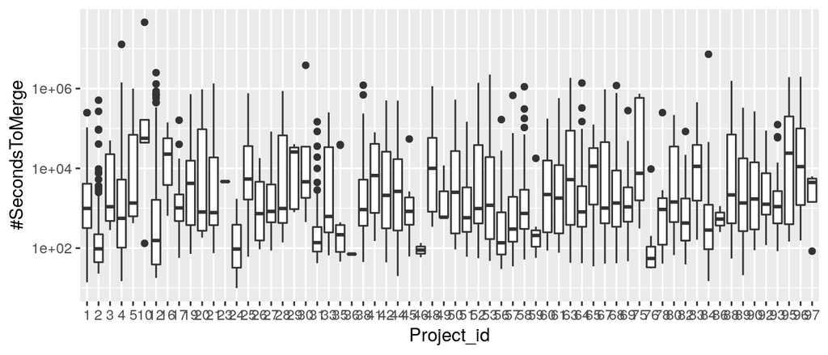

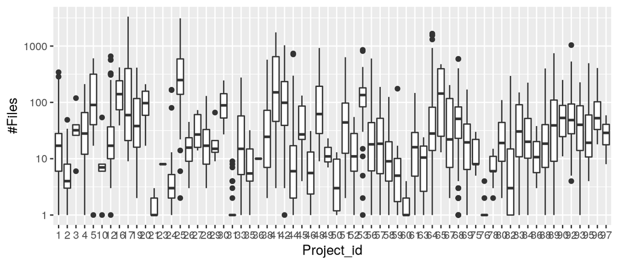

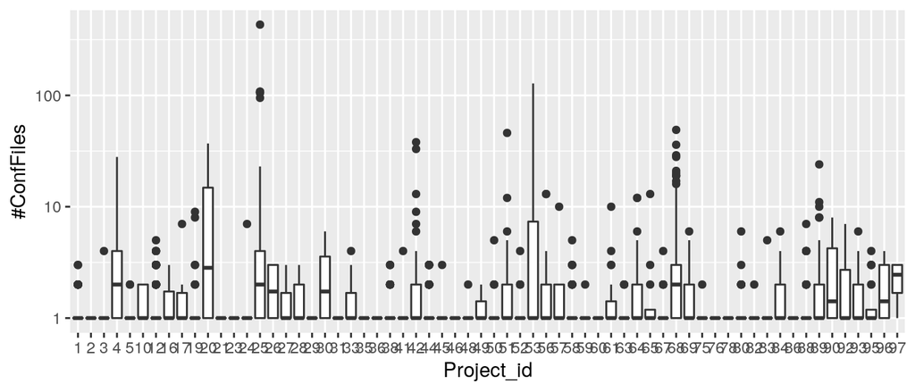

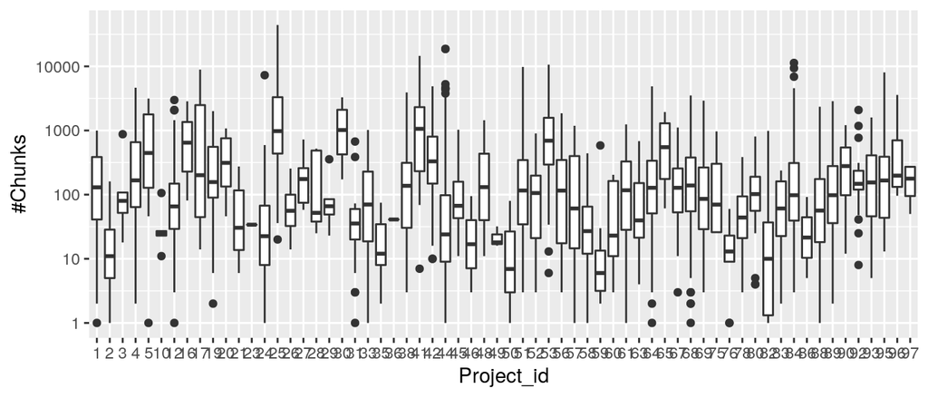

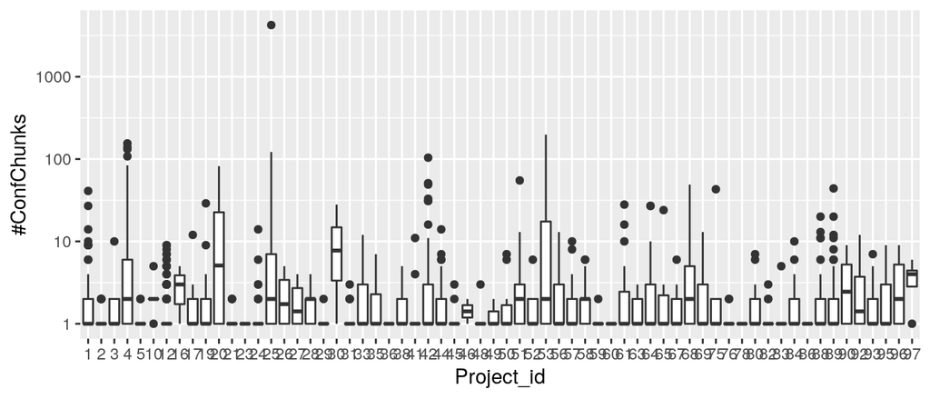

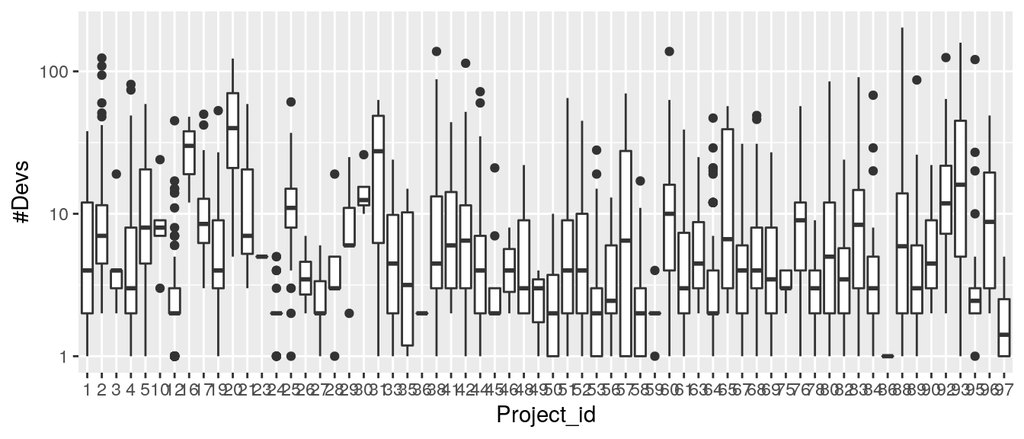

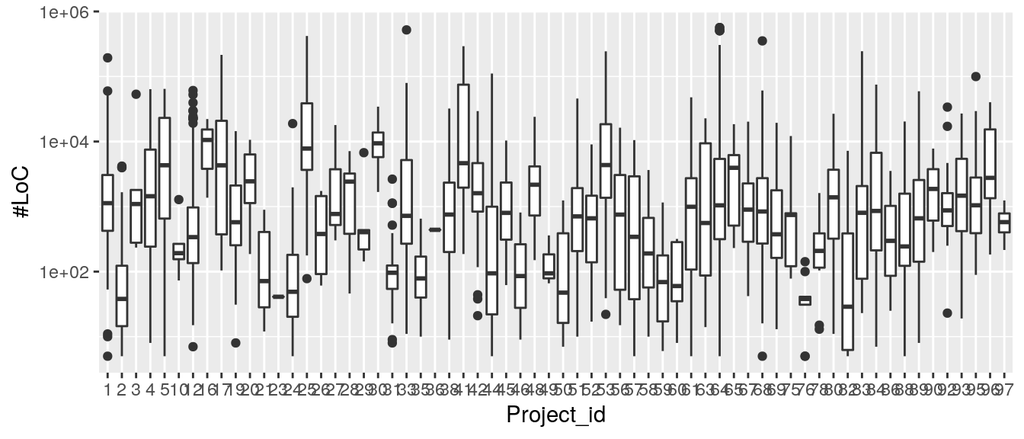

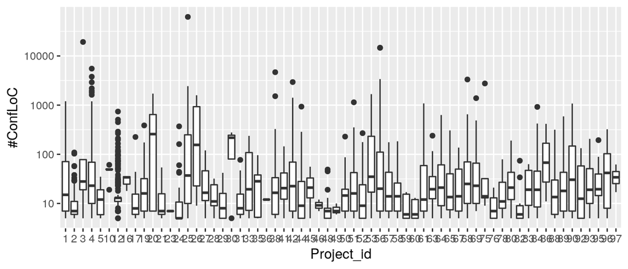

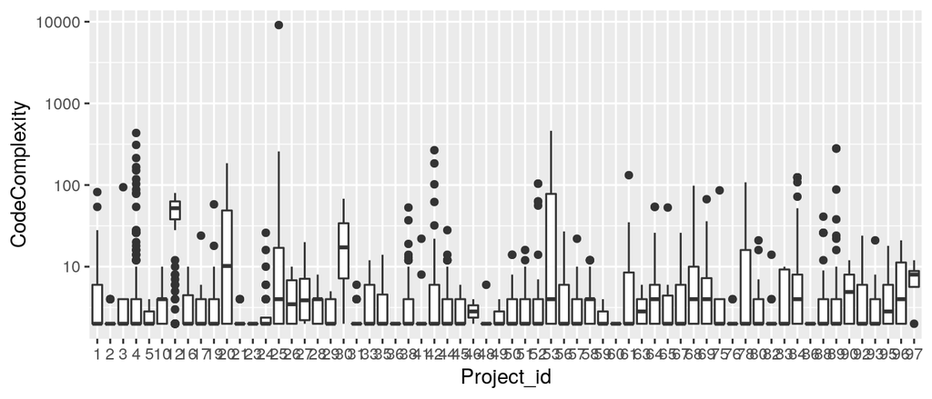

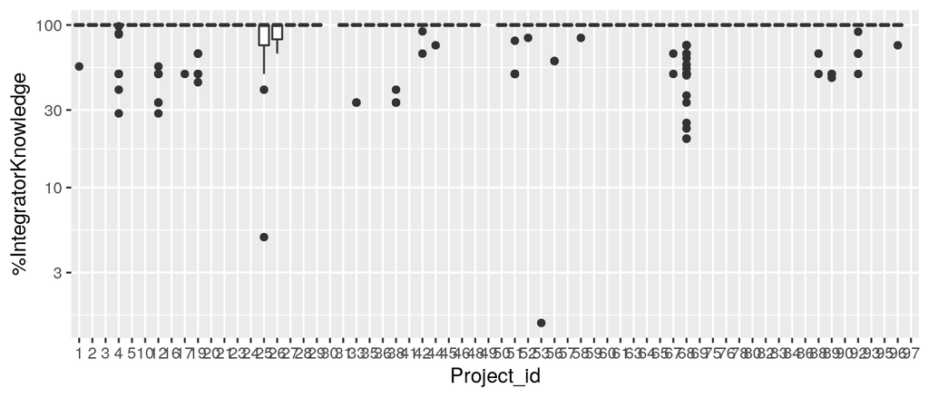

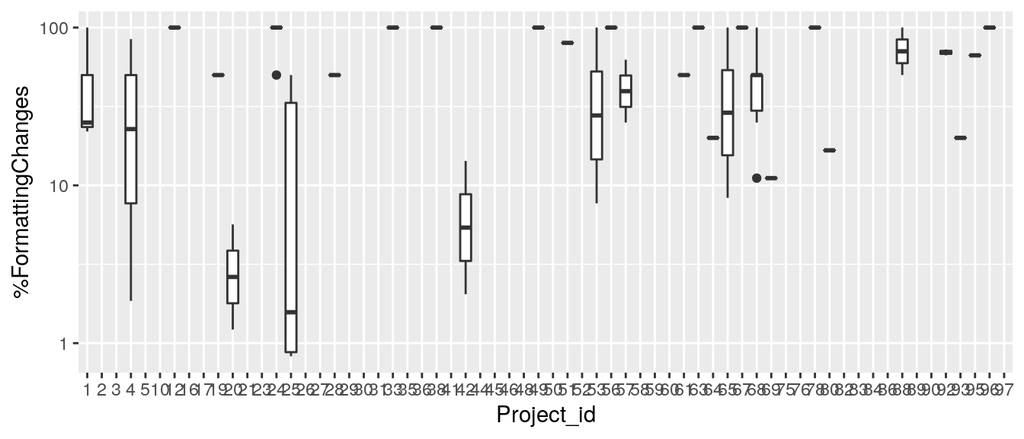

## Correlation

We start with a rank correlation of the number of conflicts and the number of communication events, using the Spearman rank-based correlation, which is invariant to any linear transformations of the covariates. In order to be able to use the same logic of correlation calculation in later PCA and SEM steps, we do not use the “Spearman”-functionality of the `cor()`-function, but manually transform the original data to ranks, and then calculate the Spearman correlation.

```r
# All metrics needed for the principal component analysis

BIG.rn                 <- c("#Files", "#ConfFiles", "#Chunks", "#ConfChunks", "#Devs", "#LoC",
                             "#ConfLoC", "CodeComplexity", "%IntegratorKnowledge", "%FormattingChanges", "#SecondsToMerge")
big                    <- c("files", "confFiles", "chunks", "confChunks", "devs", "code_churn",
                             "confCodeChurn", "complexity", "integrator.knew", "formatting")
BIG                    <- c( big, "merge.time.diff")

rank.transform  <- function(dat, big){

  r.dat       <- dat
  r.dat[,big] <- sapply(dat[,big],rank)
  return(r.dat)

}

R.DAT.rn     <- rank.transform(DAT.rn, BIG.rn)
R.DAT        <- rank.transform(DAT, BIG)
```

DAT: Rank correlation matrix

|  | #Files | #ConfFiles | #Chunks | #ConfChunks | #Devs | #LoC | #ConfLoC | CodeComplexity | %IntegratorKnowledge | %FormattingChanges | #SecondsToMerge |
| --- | --- | --- | --- | --- | --- | --- | --- | --- | --- | --- | --- |
| #Files | 1 |  |  |  |  |  |  |  |  |  |  |
| #ConfFiles | 0.374 | 1 |  |  |  |  |  |  |  |  |  |
| #Chunks | 0.883 | 0.366 | 1 |  |  |  |  |  |  |  |  |
| #ConfChunks | 0.341 | 0.852 | 0.367 | 1 |  |  |  |  |  |  |  |
| #Devs | 0.413 | 0.063 | 0.449 | 0.073 | 1 |  |  |  |  |  |  |
| #LoC | 0.854 | 0.351 | 0.909 | 0.361 | 0.412 | 1 |  |  |  |  |  |
| #ConfLoC | 0.343 | 0.575 | 0.407 | 0.687 | 0.107 | 0.439 | 1 |  |  |  |  |
| CodeComplexity | 0.281 | 0.495 | 0.27 | 0.6 | -0.09 | 0.266 | 0.57 | 1 |  |  |  |
| %IntegratorKnowledge | 0.069 | 0.032 | 0.038 | 0.028 | -0.005 | 0.008 | -0.043 | 0.115 | 1 |  |  |
| %FormattingChanges | 0.043 | 0.064 | 0.069 | 0.108 | 0.012 | 0.057 | 0.081 | 0.065 | -0.031 | 1 |  |
| #SecondsToMerge | 0.27 | 0.18 | 0.279 | 0.194 | 0.228 | 0.308 | 0.206 | 0.061 | -0.014 | 0.023 | 1 |

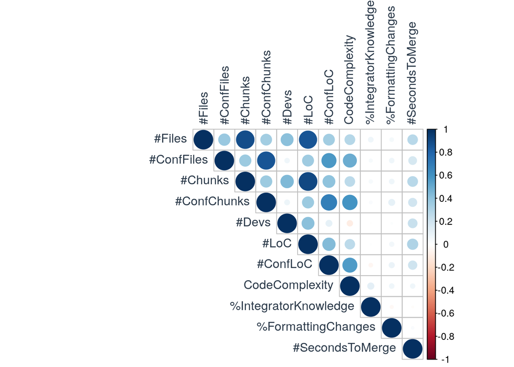

The correlation computation is complemented by a hypothesis test for the core variables of interest i.e., `#Files`, `#ConfFiles`, `#Chunks`, `#ConfChunks`, `#Devs`, `#LoC`, `#ConfLoC`, `#CodeComplexity`, `%IntegratorKnowledge`, `%FormattingChanges`.

```r
our.cor.test <- function(r.dat, com.measure){
  result <- cor.test(r.dat[,"#SecondsToMerge"], r.dat[,com.measure],
                     alternative = "two.sided", method = "spearman",
                     exact = NULL, conf.level = 0.95, continuity = FALSE)
  return(result)
}

# Number of Files:
our.cor.test(R.DAT.rn, "#Files")
```

```
##
##  Spearman's rank correlation rho
##
## data:  r.dat[, "#SecondsToMerge"] and r.dat[, com.measure]
## S = 2157500000, p-value < 2.2e-16
## alternative hypothesis: true rho is not equal to 0
## sample estimates:
##       rho
## 0.2702302
```

```r
# Number of conflicting Files:
our.cor.test(R.DAT.rn, "#ConfFiles")
```

```
##
##  Spearman's rank correlation rho
##
## data:  r.dat[, "#SecondsToMerge"] and r.dat[, com.measure]
## S = 2425100000, p-value < 2.2e-16
## alternative hypothesis: true rho is not equal to 0
## sample estimates:
##       rho
## 0.1797169
```

```r
# Number of Chunks:
our.cor.test(R.DAT.rn, "#Chunks")
```

```
##
##  Spearman's rank correlation rho
##
## data:  r.dat[, "#SecondsToMerge"] and r.dat[, com.measure]
## S = 2130200000, p-value < 2.2e-16
## alternative hypothesis: true rho is not equal to 0
## sample estimates:
##       rho
## 0.2794688
```

```r
# Number of conflicting Chunks:
our.cor.test(R.DAT.rn, "#ConfChunks")
```

```
##
##  Spearman's rank correlation rho
##
## data:  r.dat[, "#SecondsToMerge"] and r.dat[, com.measure]
## S = 2381800000, p-value < 2.2e-16
## alternative hypothesis: true rho is not equal to 0
## sample estimates:
##       rho
## 0.1943638
```

```r
# Number of Devs:
our.cor.test(R.DAT.rn, "#Devs")
```

```
##
##  Spearman's rank correlation rho
##
## data:  r.dat[, "#SecondsToMerge"] and r.dat[, com.measure]
## S = 2283500000, p-value < 2.2e-16
## alternative hypothesis: true rho is not equal to 0
## sample estimates:
##       rho
## 0.2276251
```

```r
# Number of lines of code:
our.cor.test(R.DAT.rn, "#LoC")
```

```
##
##  Spearman's rank correlation rho
##
## data:  r.dat[, "#SecondsToMerge"] and r.dat[, com.measure]
## S = 2045300000, p-value < 2.2e-16
## alternative hypothesis: true rho is not equal to 0
## sample estimates:
##       rho
## 0.3081888
```

```r
# Number of conflicting lines of code:
our.cor.test(R.DAT.rn, "#ConfLoC")
```

```
##
##  Spearman's rank correlation rho
##
## data:  r.dat[, "#SecondsToMerge"] and r.dat[, com.measure]
## S = 2348200000, p-value < 2.2e-16
## alternative hypothesis: true rho is not equal to 0
## sample estimates:
##       rho
## 0.2057337
```

```r
# Cyclomatic complexity:
our.cor.test(R.DAT.rn, "CodeComplexity")
```

```
##
##  Spearman's rank correlation rho
##
## data:  r.dat[, "#SecondsToMerge"] and r.dat[, com.measure]
## S = 2776400000, p-value = 0.001859
## alternative hypothesis: true rho is not equal to 0
## sample estimates:
##        rho
## 0.06090648
```

```r
# The percentage of knowledge of the integrator:
our.cor.test(R.DAT.rn, "%IntegratorKnowledge")
```

```
##
##  Spearman's rank correlation rho
##
## data:  r.dat[, "#SecondsToMerge"] and r.dat[, com.measure]
## S = 2996600000, p-value = 0.4883
## alternative hypothesis: true rho is not equal to 0
## sample estimates:
##         rho
## -0.01357496
```

```r
# The percentage of formatting changes:
our.cor.test(R.DAT.rn, "%FormattingChanges")
```

```
##
##  Spearman's rank correlation rho
##
## data:  r.dat[, "#SecondsToMerge"] and r.dat[, com.measure]
## S = 2889900000, p-value = 0.2505
## alternative hypothesis: true rho is not equal to 0
## sample estimates:
##        rho
## 0.02251211
```

# Principal Component Analysis (PCA)

The Principal Component Analysis (PCA) is based on a correlation matrix. To avoid bias due to distribution of the data, we use the rank transformed data in correlation estimation.

```r
fit.BIG        <- princomp(R.DAT.rn[,BIG.rn], cor=TRUE)

summary(fit.BIG)
```

```
## Importance of components:
##                        Comp.1 Comp.2 Comp.3 Comp.4 Comp.5 Comp.6 Comp.7 Comp.8
## Standard deviation      2.068  1.376 1.0286 0.9855 0.9349 0.8246 0.7248 0.6140
## Proportion of Variance  0.389  0.172 0.0962 0.0883 0.0795 0.0618 0.0478 0.0343
## Cumulative Proportion   0.389  0.561 0.6572 0.7455 0.8250 0.8868 0.9346 0.9688
##                        Comp.9 Comp.10 Comp.11
## Standard deviation     0.3764  0.3423 0.28997
## Proportion of Variance 0.0129  0.0107 0.00764
## Cumulative Proportion  0.9817  0.9924 1.00000
```

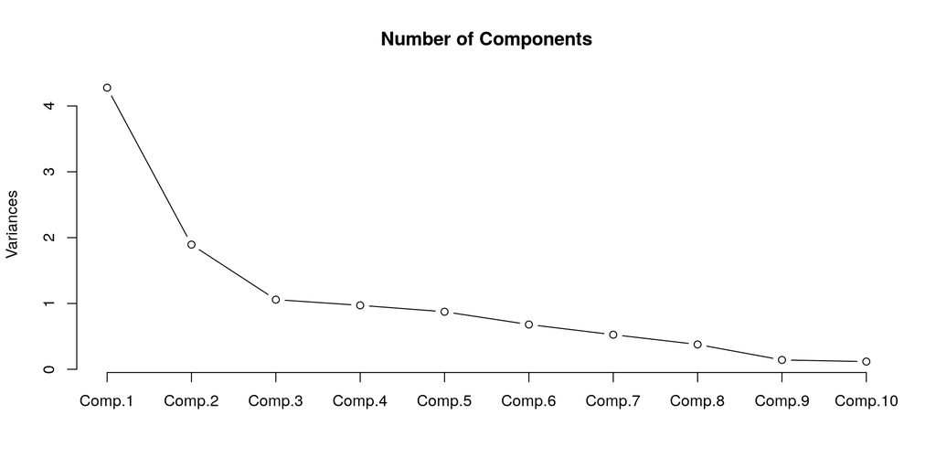

```r
par(mfrow=c(1,1))
plot(fit.BIG, type = "lines", main = "Number of Components")
```

With the function `PCA()` from the package `FactoMineR`, plot functionality is better.

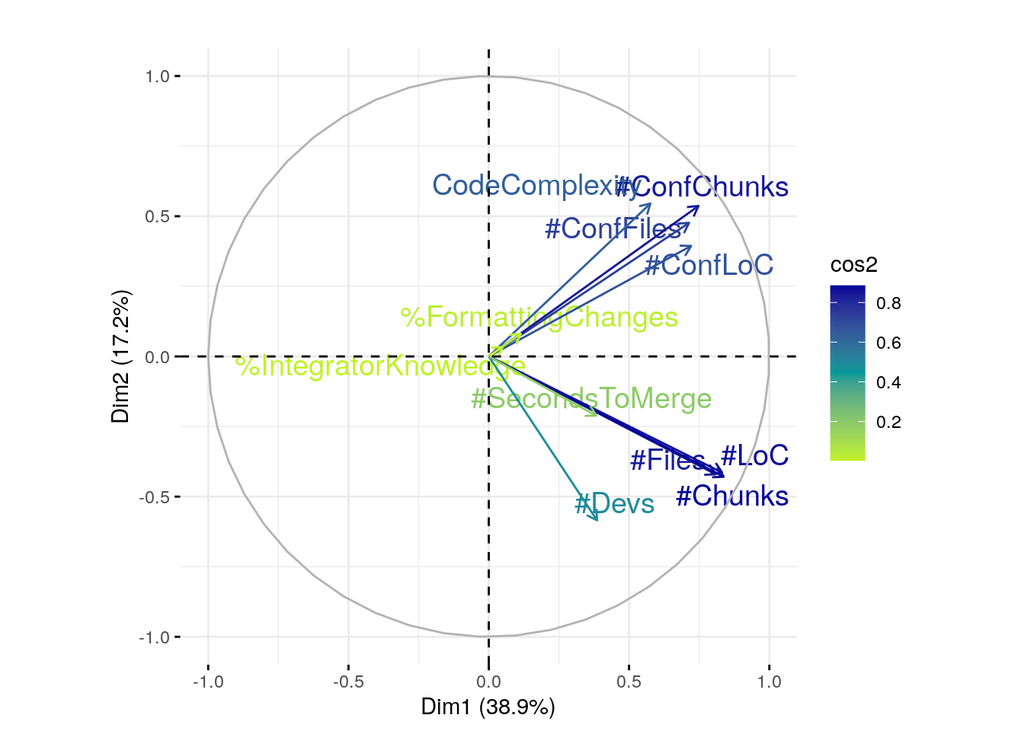

```r
#For all metrics
PCA.BIG     <- PCA(R.DAT.rn[,BIG.rn], graph = FALSE)

library(factoextra)
#pdf('PCA_results_6inch.pdf', width=6, height = 6)
par(mar = c(1,1,2,0.1))
fviz_pca_var(PCA.BIG, col.var="cos2", labelsize= 5, gradient.cols = c("#C0F228", "#009999", "#000099"), repel = TRUE, title = "")
```

```r
#dev.off()
```

This figure shows the two dimensional output from the principal component analysis for each communication approach, which covers 56.1% (38.9% + 17.2%) of the total variance of our data. The arrows represent the weights of each variable in the respective principal component and its color represents the square cosine (cos2). The square cosine represents the share of original variation in the variable that is retained in the dimensionality reduction. The longer the arrow, the larger is the share of a variable’s variance. Arrows pointing to the same direction have a large share of common variance and can be assumed to belong to the same group.

# Multiple Regression Model

Multiple linear regression is used to predict a dependent variable (y) - also called outcome variable - on the basis of multiple distinct independent variables (x) - also called predictor variables. The following equation represents a multiple linear regression model:

`y = b0 + b1*x1 + b2*x2 + b3*x3 + ... + bn*xn`

The “b” values are called the regression weights (or beta coefficients). They measure the association between the predictor variable and the outcome variable. “b_j” can be interpreted as the average effect on y of a one unit increase in “x_j”, holding all other predictors fixed [James:2014].

[James:2014] James, Gareth, Daniela Witten, Trevor Hastie, and Robert Tibshirani. 2014. An Introduction to Statistical Learning: With Applications in R. Springer Publishing Company, Incorporated.

```r
full.model <- lm(formula = `#SecondsToMerge` ~ `#Files` + `#ConfFiles` + `#Chunks` + `#ConfChunks` + `#Devs` + `#LoC` + `#ConfLoC`+ `CodeComplexity` + `%IntegratorKnowledge` + `%FormattingChanges`, data = R.DAT.rn)
summary(full.model)
```

```
##
## Call:
## lm(formula = `#SecondsToMerge` ~ `#Files` + `#ConfFiles` + `#Chunks` +
##     `#ConfChunks` + `#Devs` + `#LoC` + `#ConfLoC` + CodeComplexity +
##     `%IntegratorKnowledge` + `%FormattingChanges`, data = R.DAT.rn)
##
## Residuals:
##     Min      1Q  Median      3Q     Max
## -1837.2  -582.3   -36.2   567.1  1734.7
##
## Coefficients:
##                         Estimate Std. Error t value Pr(>|t|)
## (Intercept)            743.47926  102.46187    7.26  5.2e-13 ***
## `#Files`                 0.05251    0.04196    1.25   0.2109
## `#ConfFiles`             0.01465    0.04532    0.32   0.7465
## `#Chunks`               -0.10127    0.05146   -1.97   0.0492 *
## `#ConfChunks`            0.12391    0.04753    2.61   0.0092 **
## `#Devs`                  0.12210    0.02154    5.67  1.6e-08 ***
## `#LoC`                   0.25385    0.04698    5.40  7.1e-08 ***
## `#ConfLoC`               0.07994    0.02800    2.86   0.0043 **
## CodeComplexity          -0.10675    0.02718   -3.93  8.8e-05 ***
## `%IntegratorKnowledge`  -0.00407    0.02135   -0.19   0.8490
## `%FormattingChanges`    -0.00481    0.06965   -0.07   0.9450
## ---
## Signif. codes:  0 '***' 0.001 '**' 0.01 '*' 0.05 '.' 0.1 ' ' 1
##
## Residual standard error: 706 on 2597 degrees of freedom
## Multiple R-squared:  0.125,  Adjusted R-squared:  0.122
## F-statistic: 37.1 on 10 and 2597 DF,  p-value: <2e-16
```

```r
simplest.model <- lm(formula = `#SecondsToMerge` ~ `#Devs` + `#LoC` + `#ConfLoC`+ `CodeComplexity`, data = R.DAT.rn)
summary(simplest.model)
```

```
##
## Call:
## lm(formula = `#SecondsToMerge` ~ `#Devs` + `#LoC` + `#ConfLoC` +
##     CodeComplexity, data = R.DAT.rn)
##
## Residuals:
##     Min      1Q  Median      3Q     Max
## -1881.3  -576.1   -27.8   563.2  1760.2
##
## Coefficients:
##                Estimate Std. Error t value Pr(>|t|)
## (Intercept)    779.0152    40.5796   19.20  < 2e-16 ***
## `#Devs`          0.1194     0.0210    5.69  1.4e-08 ***
## `#LoC`           0.2176     0.0226    9.63  < 2e-16 ***
## `#ConfLoC`       0.1331     0.0241    5.52  3.8e-08 ***
## CodeComplexity  -0.0673     0.0249   -2.70    0.007 **
## ---
## Signif. codes:  0 '***' 0.001 '**' 0.01 '*' 0.05 '.' 0.1 ' ' 1
##
## Residual standard error: 708 on 2603 degrees of freedom
## Multiple R-squared:  0.118,  Adjusted R-squared:  0.116
## F-statistic: 86.7 on 4 and 2603 DF,  p-value: <2e-16
```

```r
balanced.model <- lm(formula = `#SecondsToMerge` ~ `#Chunks` + `#ConfChunks` + `#Devs` + `#LoC` + `CodeComplexity`, data = R.DAT.rn)
summary(balanced.model)
```

```
##
## Call:
## lm(formula = `#SecondsToMerge` ~ `#Chunks` + `#ConfChunks` +
##     `#Devs` + `#LoC` + CodeComplexity, data = R.DAT.rn)
##
## Residuals:
##     Min      1Q  Median      3Q     Max
## -1822.3  -584.5   -42.4   564.8  1751.4
##
## Coefficients:
##                Estimate Std. Error t value Pr(>|t|)
## (Intercept)    738.4832    41.4377   17.82  < 2e-16 ***
## `#Chunks`       -0.0783     0.0453   -1.73   0.0841 .
## `#ConfChunks`    0.1782     0.0275    6.48  1.1e-10 ***
## `#Devs`          0.1251     0.0214    5.83  6.0e-09 ***
## `#LoC`           0.2931     0.0442    6.63  3.9e-11 ***
## CodeComplexity  -0.0841     0.0257   -3.28   0.0011 **
## ---
## Signif. codes:  0 '***' 0.001 '**' 0.01 '*' 0.05 '.' 0.1 ' ' 1
##
## Residual standard error: 706 on 2602 degrees of freedom
## Multiple R-squared:  0.122,  Adjusted R-squared:  0.12
## F-statistic: 72.3 on 5 and 2602 DF,  p-value: <2e-16
```

```r
lm.fit <- lm(formula = `#SecondsToMerge` ~ `#Chunks` + `#ConfChunks` + `#Devs` + `#LoC` + `CodeComplexity`, data = R.DAT.rn)

#get_mse(lm.fit)


# checking if the simplified model covers all the variance that the full model covers
anova(simplest.model, full.model)
```

```
## Analysis of Variance Table
##
## Model 1: `#SecondsToMerge` ~ `#Devs` + `#LoC` + `#ConfLoC` + CodeComplexity
## Model 2: `#SecondsToMerge` ~ `#Files` + `#ConfFiles` + `#Chunks` + `#ConfChunks` +
##     `#Devs` + `#LoC` + `#ConfLoC` + CodeComplexity + `%IntegratorKnowledge` +
##     `%FormattingChanges`
##   Res.Df      RSS Df Sum of Sq    F Pr(>F)
## 1   2603 1.30e+09
## 2   2597 1.29e+09  6  11174613 3.74  0.001 **
## ---
## Signif. codes:  0 '***' 0.001 '**' 0.01 '*' 0.05 '.' 0.1 ' ' 1
```

```r
# checking if the simplified model covers all the variance that the full model covers
anova(simplest.model, balanced.model)
```

```
## Analysis of Variance Table
##
## Model 1: `#SecondsToMerge` ~ `#Devs` + `#LoC` + `#ConfLoC` + CodeComplexity
## Model 2: `#SecondsToMerge` ~ `#Chunks` + `#ConfChunks` + `#Devs` + `#LoC` +
##     CodeComplexity
##   Res.Df     RSS Df Sum of Sq    F  Pr(>F)
## 1   2603 1.3e+09
## 2   2602 1.3e+09  1   6578524 13.2 0.00029 ***
## ---
## Signif. codes:  0 '***' 0.001 '**' 0.01 '*' 0.05 '.' 0.1 ' ' 1
```

```r
# checking if the partial model covers all the variance that the full model covers
anova(balanced.model, full.model)
```

```
## Analysis of Variance Table
##
## Model 1: `#SecondsToMerge` ~ `#Chunks` + `#ConfChunks` + `#Devs` + `#LoC` +
##     CodeComplexity
## Model 2: `#SecondsToMerge` ~ `#Files` + `#ConfFiles` + `#Chunks` + `#ConfChunks` +
##     `#Devs` + `#LoC` + `#ConfLoC` + CodeComplexity + `%IntegratorKnowledge` +
##     `%FormattingChanges`
##   Res.Df      RSS Df Sum of Sq    F Pr(>F)
## 1   2602 1.30e+09
## 2   2597 1.29e+09  5   4596089 1.85    0.1
```

For a given the independent variable (predictor), the t-statistic evaluates whether or not there is significant association between the predictor and the independent variable (outcome variable), that is whether the beta coefficient of the predictor is significantly different from zero.

It can be seen that, changing in `#Devs`, `#LoC`, `#ConfLoC`, and `CodeComplexity` variables are significantly associated to the time (in seconds) - `#SecondsToMerge` - to solve the merge conflicts. The most interested point here is that increasing `#Devs`, `#LoC`, `#ConfLoC` also increases the time to resolve merge conflicts, however, for to `CodeComplexity` the relationship is oposite. In other words, increasing the `CodeComplexity` of conflicting Chunks leads to less time to resolve merge conflicts.

For a given predictor variable, the coefficient (b) can be interpreted as the average effect on y of a one unit increase in predictor, holding all other predictors fixed. For example, Adding 1,000 LoC in the merge scenario is associated with an increase in time by approximately 293 seconds or 5 minutes to solve the merge conflicts, for a fixed amount of `#ConfChunks`, `#Chunks`, `#Devs`, and `CodeComplexity`, on average.

R-squared is a statistical measure of how close the data are to the fitted regression line. It is also known as the coefficient of determination, or the coefficient of multiple determination for multiple regression. In multiple linear regression, the R-squared (R2) represents the correlation coefficient between the observed values of the outcome variable (y) and the fitted (i.e., predicted) values of y. For this reason, the value of R will always be positive and will range from zero to one. R2 represents the proportion of variance, in the outcome variable y, that may be predicted by knowing the value of the x variables. An R2 value close to 1 indicates that the model explains a large portion of the variance in the outcome variable.

Examine the F-statistic and the associated p-value, at the bottom of model summary. In our example, it can be seen that p-value of the F-statistic is < 2.2e-16, which is highly significant. This means that, at least, one of the predictor variables is significantly related to the outcome variable.

Anova (analysis of variance) - The p-value is not significant, so, this means that adding other variables we are not adding relevant information to the regression model.

```
##                           2.5 %    97.5 %
## (Intercept)            542.5640 944.39447
## `#Files`                -0.0298   0.13479
## `#ConfFiles`            -0.0742   0.10352
## `#Chunks`               -0.2022  -0.00036
## `#ConfChunks`            0.0307   0.21710
## `#Devs`                  0.0799   0.16434
## `#LoC`                   0.1617   0.34597
## `#ConfLoC`               0.0250   0.13484
## CodeComplexity          -0.1600  -0.05346
## `%IntegratorKnowledge`  -0.0459   0.03780
## `%FormattingChanges`    -0.1414   0.13178
```

# Effect Size

The code bellow compute the effect size

```r
effectsize::cohens_f(balanced.model)
```

```
## Parameter      | Cohen's f (partial) |       90% CI
## ---------------------------------------------------
## #Chunks        |                0.30 | [0.27, 0.33]
## #ConfChunks    |                0.11 | [0.07, 0.14]
## #Devs          |                0.13 | [0.10, 0.17]
## #LoC           |                0.13 | [0.10, 0.16]
## CodeComplexity |                0.06 | [0.03, 0.10]
```

```r
#chisq.test(balanced.model)

#effectsize(balanced.model, type=NULL)

anova_stats(balanced.model)
```

```
## term           |   df |     sumsq |    meansq | statistic | p.value | etasq | partial.etasq | omegasq | partial.omegasq | epsilonsq | cohens.f | power
## ------------------------------------------------------------------------------------------------------------------------------------------------------
## `#Chunks`      |    1 | 1.155e+08 | 1.155e+08 |   231.453 |  < .001 | 0.078 |         0.082 |   0.078 |           0.081 |     0.078 |    0.298 | 1.000
## `#ConfChunks`  |    1 | 1.441e+07 | 1.441e+07 |    28.879 |  < .001 | 0.010 |         0.011 |   0.009 |           0.011 |     0.009 |    0.105 | 1.000
## `#Devs`        |    1 | 2.349e+07 | 2.349e+07 |    47.091 |  < .001 | 0.016 |         0.018 |   0.016 |           0.017 |     0.016 |    0.135 | 1.000
## `#LoC`         |    1 | 2.159e+07 | 2.159e+07 |    43.272 |  < .001 | 0.015 |         0.016 |   0.014 |           0.016 |     0.014 |    0.129 | 1.000
## CodeComplexity |    1 | 5.357e+06 | 5.357e+06 |    10.739 |   0.001 | 0.004 |         0.004 |   0.003 |           0.004 |     0.003 |    0.064 | 0.906
## Residuals      | 2602 | 1.298e+09 | 4.988e+05 |           |         |       |               |         |                 |           |          |
```

```r
anova_stats(full.model)
```

```
## term                   |   df |     sumsq |    meansq | statistic | p.value | etasq | partial.etasq | omegasq | partial.omegasq | epsilonsq | cohens.f | power
## --------------------------------------------------------------------------------------------------------------------------------------------------------------
## `#Files`               |    1 | 1.079e+08 | 1.079e+08 |   216.754 |  < .001 | 0.073 |         0.077 |   0.073 |           0.076 |     0.073 |    0.289 | 1.000
## `#ConfFiles`           |    1 | 1.066e+07 | 1.066e+07 |    21.409 |  < .001 | 0.007 |         0.008 |   0.007 |           0.008 |     0.007 |    0.091 | 0.996
## `#Chunks`              |    1 | 9.540e+06 | 9.540e+06 |    19.156 |  < .001 | 0.006 |         0.007 |   0.006 |           0.007 |     0.006 |    0.086 | 0.992
## `#ConfChunks`          |    1 | 4.906e+06 | 4.906e+06 |     9.851 |   0.002 | 0.003 |         0.004 |   0.003 |           0.003 |     0.003 |    0.062 | 0.881
## `#Devs`                |    1 | 2.275e+07 | 2.275e+07 |    45.684 |  < .001 | 0.015 |         0.017 |   0.015 |           0.017 |     0.015 |    0.133 | 1.000
## `#LoC`                 |    1 | 1.942e+07 | 1.942e+07 |    38.990 |  < .001 | 0.013 |         0.015 |   0.013 |           0.014 |     0.013 |    0.123 | 1.000
## `#ConfLoC`             |    1 | 1.705e+06 | 1.705e+06 |     3.424 |   0.064 | 0.001 |         0.001 |   0.001 |           0.001 |     0.001 |    0.036 | 0.456
## CodeComplexity         |    1 | 7.939e+06 | 7.939e+06 |    15.941 |  < .001 | 0.005 |         0.006 |   0.005 |           0.006 |     0.005 |    0.078 | 0.979
## `%IntegratorKnowledge` |    1 | 17653.655 | 17653.655 |     0.035 |   0.851 | 0.000 |         0.000 |   0.000 |           0.000 |     0.000 |    0.004 | 0.054
## `%FormattingChanges`   |    1 |  2371.948 |  2371.948 |     0.005 |   0.945 | 0.000 |         0.000 |   0.000 |           0.000 |     0.000 |    0.001 | 0.051
## Residuals              | 2597 | 1.293e+09 | 4.980e+05 |           |         |       |               |         |                 |           |          |
```

```r
anova_stats(simplest.model)
```

```
## term           |   df |     sumsq |    meansq | statistic | p.value | etasq | partial.etasq | omegasq | partial.omegasq | epsilonsq | cohens.f | power
## ------------------------------------------------------------------------------------------------------------------------------------------------------
## `#Devs`        |    1 | 7.659e+07 | 7.659e+07 |   152.829 |  < .001 | 0.052 |         0.055 |   0.051 |           0.055 |     0.051 |    0.242 | 1.000
## `#LoC`         |    1 | 8.186e+07 | 8.186e+07 |   163.335 |  < .001 | 0.055 |         0.059 |   0.055 |           0.059 |     0.055 |    0.250 | 1.000
## `#ConfLoC`     |    1 | 1.162e+07 | 1.162e+07 |    23.179 |  < .001 | 0.008 |         0.009 |   0.008 |           0.008 |     0.008 |    0.094 | 0.998
## CodeComplexity |    1 | 3.648e+06 | 3.648e+06 |     7.278 |   0.007 | 0.002 |         0.003 |   0.002 |           0.002 |     0.002 |    0.053 | 0.770
## Residuals      | 2603 | 1.305e+09 | 5.012e+05 |           |         |       |               |         |                 |           |          |
```